# How to interpret R linear regression analysis output in simplified way (lm output point by point)

Vineet Jaiswal

August 12, 2017

## Explain LM magic

I am explaining LM magic in less words, hope it will be helpful for you.

### Beginning with data selection

```r
library(alr3)
```

```r
library(corrplot)
data(water) ## load the data
head(water) ## view the data
```

```
##   Year APMAM APSAB APSLAKE OPBPC  OPRC OPSLAKE  BSAAM
## 1 1948  9.13  3.58    3.91  4.10  7.43    6.47  54235
## 2 1949  5.28  4.82    5.20  7.55 11.11   10.26  67567
## 3 1950  4.20  3.77    3.67  9.52 12.20   11.35  66161
## 4 1951  4.60  4.46    3.93 11.14 15.15   11.13  68094
## 5 1952  7.15  4.99    4.88 16.34 20.05   22.81 107080
## 6 1953  9.70  5.65    4.91  8.88  8.15    7.41  67594
```

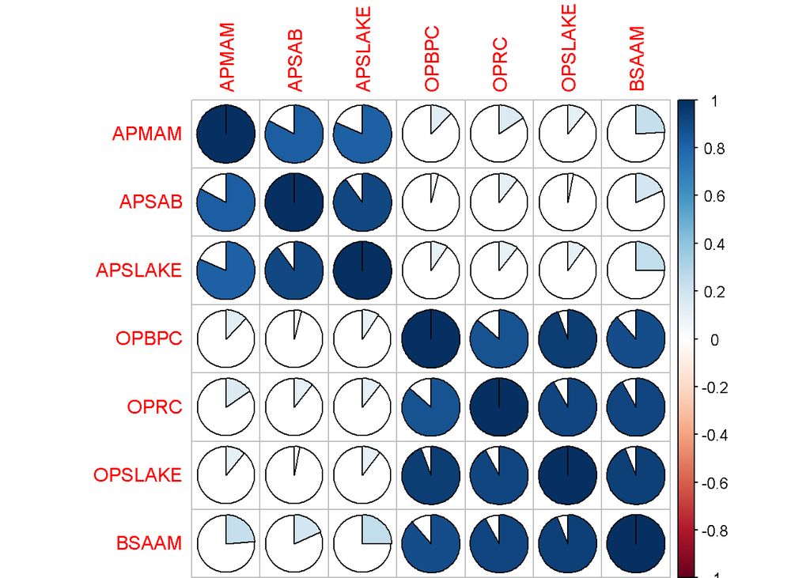

```r
filter.water <- water[,-1] ## Remove unwanted year
corrplot(cor(filter.water), method = "pie") ## check correlation of the data
```

### The Magic : Mutlivariable linear regression

```r
mlr <- lm(BSAAM~., data = filter.water)
summary(mlr)
```

```
##
## Call:
## lm(formula = BSAAM ~ ., data = filter.water)
##
## Residuals:
##    Min     1Q Median     3Q    Max
## -12690  -4936  -1424   4173  18542
##
## Coefficients:
##             Estimate Std. Error t value Pr(>|t|)
## (Intercept) 15944.67    4099.80   3.889 0.000416 ***
## APMAM         -12.77     708.89  -0.018 0.985725
## APSAB        -664.41    1522.89  -0.436 0.665237
## APSLAKE      2270.68    1341.29   1.693 0.099112 .
## OPBPC          69.70     461.69   0.151 0.880839
## OPRC         1916.45     641.36   2.988 0.005031 **
## OPSLAKE      2211.58     752.69   2.938 0.005729 **
## ---
## Signif. codes:  0 '***' 0.001 '**' 0.01 '*' 0.05 '.' 0.1 ' ' 1
##
## Residual standard error: 7557 on 36 degrees of freedom
## Multiple R-squared:  0.9248, Adjusted R-squared:  0.9123
## F-statistic: 73.82 on 6 and 36 DF,  p-value: < 2.2e-16
```

here it is like yi = b0 + b1xi1 + b2xi2 + … bpxip + ei for i = 1,2, … n. here y = BSAAM and x1…xn is all other variables

### Explained and normal interpretation

#### Called function

This is normal r script which you ran above

```r
#Call
# lm(formula = BSAAM ~ ., data = filter.water)
```

#### Residuals

Normally it gives a basic idea about residuals, like minimum, first quarter, median, third quarter and max value, normally it does not used in our analysis

Note : Residuals are essentially the difference between the actual observed response values and the response values that the model predicted

```r
#Residuals:
#   Min     1Q   Median   3Q    Max
# -12690  -4936  -1424   4173  18542
```

#### Coefficients-Intercept

We can see a all the remaining variable comes with one more row ‘Intercept’, Intercept is giving data when all the variables are 0 so all the measure done without considering any variable, this is again not much used in normal cases

its average value of y when x = 0

```r
#            Estimate    Std. Error t value Pr(>|t|)
# (Intercept) 15944.67    4099.80   3.889 0.000416 ***
```

#### Coefficient-Estimate

I am taking only one variable for explanation

```r
#             Estimate
# OPSLAKE      2211.58
```

This is a one unit increase in X then expected change in Y, in this case one unit change in OPLAKE then 2211.58 unit change in BSAAM

#### Coefficient-Std. Error

```r
#           Std. Error
#OPSLAKE    752.69
```

Estimate of variability in a coefficient due to sampling variability Average amount that the coefficient estimates vary from the actual average value of our response variable. During sampling process, different sample may have different coefficient so its all majored by standard error.

Low value of this error will be helpful for our analysis, also used for checking confidence interval

#### Coefficient-t value

```r
#           t value
#OPSLAKE    2.938
```

t value = estimate/std error

high t value will be helpful for our analysis as this would indicate we could reject the null hypothesis, it is using to calculate p value

#### Coefficient Pr(>|t|)

```r
#           Pr(>|t|)
#OPSLAKE    0.005729 **
```

individual p value for each parameter to accept or reject null hypothesis, this is statistical estimate of x and y. Lower the p value allow us to reject null hypothesis. all type of errors (true positive/negative, false positive/negative) are come to picture if we wrongly analysis p value

https://en.wikipedia.org/wiki/P-value

asterisks mark aside p value define significance of value, lower the value have high significance

```r
# Signif. codes:  0 '***' 0.001 '**' 0.01 '*' 0.05 '.' 0.1 ' ' 1
```

### Residual standard error

```r
# Residual standard error: 7557 on 36 degrees of freedom
```

In normal work, average error of a model, how well our model is doing to predict the data on average

Degree of freedom is like no of data point taken in consideration for estimation taking parameter in account

Not sure but in this case, we total have 43 data point and 7 variable so removed 7 data points (43-7) = 36 degree of freedom

#### Multiple R-squared adnd Adjusted R-squared

```r
# Multiple R-squared:  0.9248,  Adjusted R-squared:  0.9123
```

Its always between 0 to 1, high value are better Percentage of variation in the response variable that is explained by variation in the explanatory variable, this is use to calculate how well the model is doing to explain the things, when we increase no of variable then it will also increase and there are no proper limit to define how much we can increase.

We are taking dusted value in which we does not take all variables, only significant variable are considered in adjusted R squared

### F-statistic

```r
# F-statistic: 73.82 on 6 and 36 DF
```

this is showing relationship between predictor and response, higher the value will give more reasons to reject null hypothesis, its significant of overall model not any specific parameter

DF - Degree of Freedom

### p-value

```r
# p-value: < 2.2e-16
```

Overall p value on the basis of F-statistic

normally p value less than 0.05 indicate that overall model is significant

I tried my best to explain all the points but I am sorry if something wrong, Please write to me if you find anything not correct here : jaiswaalvineet@gmail.com